# IIIT Vadodara

## Winter 2021-22

## CS 612, CS 652, CS/IT 308 Machine Learning

## Lab#3 Principal component analysis (PCA) and Data generating process

```python
%matplotlib inline
import numpy as np
import matplotlib.pyplot as plt
from scipy import misc
from numpy import linalg as la
import matplotlib.image as mpimg
import glob
from numpy import linalg as LA
import scipy.io as sio
from mpl_toolkits import mplot3d
import random
```

## 1. Implement PCA for 2D Data.

In this experiment consider 200 samples and obtain the matrix $X$ in $X = C \times D$, where $C=\begin{bmatrix} 1 & 2 \\ 1 & 1 \end{bmatrix}$ and $D$ is the randomly generated matix using samples.

Hint for Code: Use np.linalg.eig, np.diag, np.matmul, np.cov

```python
# 2D Data for example
# Find X

#randomly generated D
D  = np.random.rand(2,200)  #(2,200)
C = np.array([[1,2], [1,1]]) #(2,2)

#obtain X
X =  np.matmul(C,D)
```

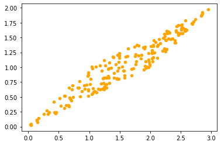

```python
# code to scatter plot X

plt.scatter(X[0],X[1],color = "orange",s=20)
```

### Implement PCA

Hint: refer class note

```python
xbar = np.array([np.mean(i) for i in X])
#print(xbar)
X_centered = np.array([X[i] - xbar[i] for i in range(len(X))])
# print(X_centered)
```

```python
# Write code to impement PCA
C_x =np.cov(X_centered)
print("variance-covariance matrix : \n",C_x)
E,P = np.linalg.eig(C_x)
id = E.argsort()[::-1]
E = E[id]
P = P[:,id]

print('eigen values=\n',E)
print('eigen vectors=\n',P)
```

```
variance-covariance matrix :
 [[0.50994876 0.31666673]
 [0.31666673 0.21349315]]
eigen values=
 [0.71136263 0.01207929]
eigen vectors=
 [[ 0.84378375 -0.53668331]
 [ 0.53668331  0.84378375]]
```

```
[[ 0.84378375 -0.53668331]
 [ 0.53668331  0.84378375]]
transpose of eigen vectors
 [[ 0.84378375  0.53668331]
 [-0.53668331  0.84378375]]
```

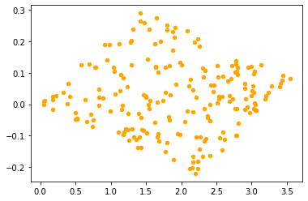

```python
# Transform data to new coordinates
print(P)
P = P.T
print("transpose of eigen vectors\n",P)


#Y = P * X
Y = np.matmul(P,X)
# print("transformed X i.e Y = \n",Y)

# scatter plot Y
plt.scatter(Y[0],Y[1],color = "orange",s=20)
```

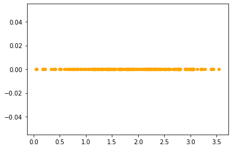

```python
#Approximate each 2-point data vector using one values
# Hint: Y[-1,:]=0
Y[-1,:] = 0
# print(Y)


# scatter plot Y
plt.scatter(Y[0],Y[1],color = "orange",s=20)
```

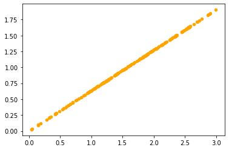

```python
#Transform back to original coordinates
PP = P.T
PP = PP[:,:-1]
YY = Y[:-1,:]

#X_approx = PP * YY

X_apprx = np.matmul(PP,YY)


# scatter plt X_approx
plt.scatter(X_apprx[0],X_apprx[1],color = "orange",s=20)
```

## 2. Implement PCA for 3D Data.

In this experiment consider 200 samples and obtain the matrix $X$ in $X = C \times D$, where $$C=\begin{bmatrix} 1&2&-1\\ 2&2&1\\ -2&0&2\\ \end{bmatrix}$$ and $D$ is the randomly generated matix using samples.

Hint for Code: Use np.linalg.eig, np.diag, np.matmul, np.cov

```python
# Write 3D Data and find X
D  = np.random.rand(3,200)  #(3,200)
C = np.array([[1,2,-1], [2,2,1],[-2,0,2]]) #(3,3)

#obtain X
X =  np.matmul(C,D)
```

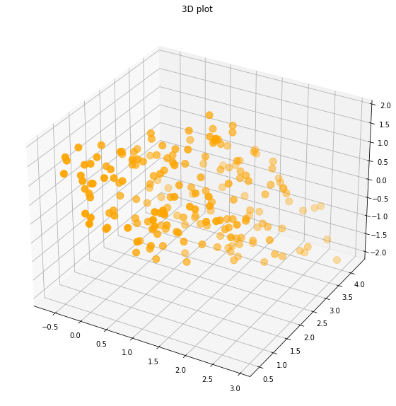

```python
# write code to scatter plot 3D
fig = plt.figure(figsize = (10, 10))
ax = plt.axes(projection ="3d")
ax.scatter3D(X[0], X[1], X[2], color = "orange",s=100)
plt.title("3D plot")
plt.show()
```

### Implement PCA

Hint: refer class note.

```python
#Write code here
xbar = np.array([np.mean(i) for i in X])
X_centered = np.array([X[i] - xbar[i] for i in range(len(X))])

C_x = np.cov(X_centered)
print("variance-covariance matrix : \n",C_x)

E,P = np.linalg.eig(C_x)
id = E.argsort()[::-1]
E = E[id]
P = P[:,id]

print('eigen values=\n',E)
print('eigen vectors=\n',P)
```

```
variance-covariance matrix :
 [[ 0.58504888  0.49942047 -0.39333577]
 [ 0.49942047  0.79860124 -0.21893647]
 [-0.39333577 -0.21893647  0.72427491]]
eigen values=
 [1.45030722 0.53991633 0.11770149]
eigen vectors=
 [[ 0.5920322   0.02511196  0.80552298]
 [ 0.62472912  0.61713283 -0.47839376]
 [-0.50912808  0.78645817  0.34967434]]
```

```
transpose of eigen vectors
 [[ 0.5920322   0.62472912 -0.50912808]
 [ 0.02511196  0.61713283  0.78645817]
 [ 0.80552298 -0.47839376  0.34967434]]
```

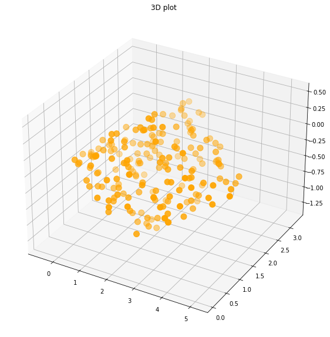

```python
# Transform data to new coordinates
P = P.T
print("transpose of eigen vectors\n",P)

# Y = P*X
Y = np.matmul(P,X)

#Scatter plt Y
fig = plt.figure(figsize = (10, 10))
ax = plt.axes(projection ="3d")
ax.scatter3D(Y[0], Y[1], Y[2], color = "orange",s=100)
plt.title("3D plot")
plt.show()
```

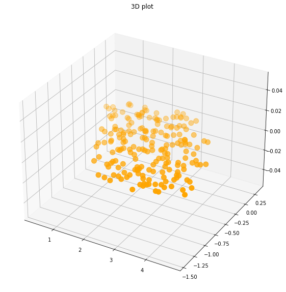

```python
#Approximate each 3-point data vector using two values
Y[2,:]=0
# print(Y)


#Scatter plot Y
fig = plt.figure(figsize = (10, 10))
ax = plt.axes(projection ="3d")
ax.scatter3D(Y[0], Y[1], Y[2], color = "orange",s=100)
plt.title("3D plot")
plt.show()
```

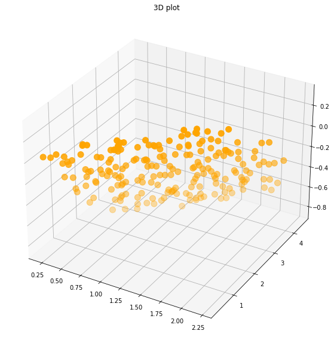

```python
#Transform back to original coordinates
PP = P.T
PP = PP[:,:-1]
YY = Y[:-1,:]
# X_approx = PP*YY

X_apprx = np.matmul(PP,YY)

#Scatter plot X_approx
fig = plt.figure(figsize = (10, 10))
ax = plt.axes(projection ="3d")
ax.scatter3D(X_apprx[0], X_apprx[1], X_apprx[2], color = "orange",s=100)
plt.title("3D plot")
plt.show()
```

## 3. Implement PCA for image compression.

```
Methodology: A set of face images is used to generate a basis matrix using PCA. Essentially this basis matrix would the input data which are correlated observations from the real world. By preserving different number of eigenvectors, different degrees of compression can be achieved.
```

You can use this link for face images:

https://drive.google.com/file/d/1XMtBihZypbE-zlg_DuAW63IF4vX4cn3d/view?usp=sharing

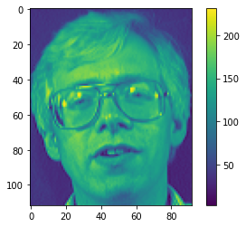

```python
a=glob.glob('PCA/*.pgm') # to read all images
X1 = mpimg.imread(a[0])
plt.imshow(X1)
plt.colorbar()
[m,n]=np.shape(X1)
X = X1.flatten()
X = np.zeros(shape=(np.size(a),m*n))
for i,j in zip(a,range(np.size(a))):
    X[j,:]=  mpimg.imread(i).flatten()
```

[output not shown]

[output cut: 14 more lines]

[output not shown]

[figure not shown]

```python
#plot Eigen values of covariance matrix
x = np.array([np.mean(i) for i in X])
X_centered = np.array([X[i] - x[i] for i in range(len(X))])

C_x = np.cov(X_centered)
print("variance-covariance matrix : \n",C_x)


E,P = np.linalg.eig(C_x)

#sort the eigen values and eigen vectors
id = E.argsort()[::-1]
E = E[id]
P = P[:,id]


print("eigen values ",E)
print("eigen vector ",P)
print("Size of P :",P.shape)


# plt.figure()
plt.plot(E)
```

```
values for how much you are droping
[ 44.43987483  55.83842131  61.78611429  66.05308352  69.77366531
  72.46549134  74.74117879  76.65786126  78.46459831  80.06878526
  81.44102626  82.70198731  83.87000868  84.96176635  85.97212146
  86.92371532  87.85418037  88.74741643  89.59743203  90.39878535
  91.16825978  91.90191994  92.57875477  93.22343473  93.86617633
  94.50298507  95.07941361  95.62651123  96.15921371  96.65399183
  97.13169692  97.58489366  97.9951886   98.37320217  98.72352726
  99.07091659  99.40109665  99.71605673 100.        ]
Enter the number of principal eigenvectors <= 12
```

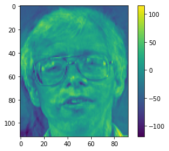

```python
#write code for PCA and approximate each data vector using few significant eigen values
P = P.T
#transpose A to Y
A=P
A = A.transpose()
Y = np.matmul(A,X_centered)


total = sum(E)
var_exp = [(i / total)*100 for i in sorted(E, reverse=True)]
cum_var_exp = np.cumsum(var_exp)

print("values for how much you are droping")
print(cum_var_exp)


q=int(input("Enter the number of principal eigenvectors <= "))
PP = A.T
PP = PP[:,:-q]
YY = Y[:-q,]

Xr= np.dot(PP,YY)

X1r = np.reshape(Xr[0,:],[m,n])
plt.imshow(X1r)
plt.colorbar()
```

### Homework: Implement PCA for remote sensing image.

```
Methodology: A set of remotely sensed images (Cuprite hyperspectral data having 188 bands) is used to generate a basis matrix based on PCA, and this matrix would be used to uncorrelate the data which are correlated. By preserving different number of eigenvectors different degrees of compression can be achieved. Find the variance of the input and output in each case and note the observations.
```

You can use this link for Cuprite images:

https://drive.google.com/file/d/1XMtBihZypbE-zlg_DuAW63IF4vX4cn3d/view?usp=sharing

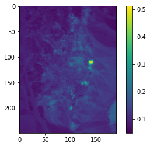

```python
X = sio.loadmat('PCA1/cuprite.mat')
X= X['x']
X1 = np.reshape(X,[188,191,250])
plt.figure()
plt.imshow(X1[1,:,:].T)
plt.colorbar()
```

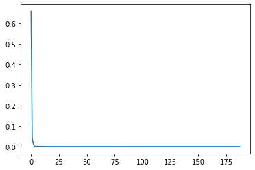

```python
#plot Eigen values of covariance matrix
x = np.array([np.mean(i) for i in X])
#centered data to mean
X_centered = np.array([X[i] - x[i] for i in range(len(X))])


C_x = np.cov(X_centered)

E,P = np.linalg.eig(C_x)
id = E.argsort()[::-1]
E = E[id]
P = P[:,id]

plt.figure()
plt.plot(E)
A = P.T
```

```
values for how much you are droping
[ 91.02515245  96.95266646  98.89364037  99.17364724  99.36686332
  99.52348163  99.65900922  99.72416824  99.77396993  99.80780027
  99.83300645  99.85125408  99.8666967   99.87771513  99.88678568
  99.89508047  99.90223781  99.90876261  99.91473979  99.91964593
  99.92399471  99.92818445  99.93212803  99.93565508  99.93899419
  99.94222499  99.94505081  99.94737955  99.94966284  99.95170823
  99.9537246   99.95558488  99.95727304  99.95886115  99.96036513
  99.9618233   99.96315049  99.96442356  99.96567178  99.96675058
  99.96776063  99.96871384  99.96963788  99.97047111  99.97128761
  99.97204484  99.97278505  99.97350849  99.97422447  99.97485843
  99.97548673  99.97610617  99.97670787  99.97729903  99.97788903
  99.97846576  99.9790285   99.97957426  99.98011009  99.98062908
  99.98113552  99.98162477  99.98210611  99.98257766  99.98303995
  99.98349372  99.98392869  99.98434548  99.98475269  99.98515617
  99.98555517  99.98593864  99.98630656  99.98665836  99.9870051
  99.98734351  99.98767355  99.98797498  99.98827468  99.98856061
  99.988832    99.98910026  99.98935887  99.98961016  99.98984647
  99.99007662  99.99030056  99.99051699  99.99072878  99.99093854
  99.99113664  99.99133049  99.99151841  99.99170497  99.99188049
  99.99204661  99.99221071  99.99236997  99.99252618  99.99268095
  99.99282754  99.99296718  99.99310282  99.99323518  99.99336637
  99.99349356  99.99361941  99.99374434  99.99386863  99.9939923
  99.99411446  99.99423618  99.99435681  99.99447687  99.99459591
  99.9947144   99.99483144  99.99494716  99.99506143  99.99517178
  99.99528145  99.99538989  99.99549648  99.99559866  99.99569927
  99.9957994   99.99589795  99.99599497  99.99609065  99.99618608
  99.99627998  99.99637215  99.99646361  99.99655448  99.99664398
  99.99673197  99.99681907  99.99690573  99.99699179  99.997077
  99.99716205  99.99724628  99.99733036  99.99741319  99.99749539
  99.99757644  99.99765686  99.99773682  99.99781633  99.99789544
  99.9979743   99.99805182  99.99812871  99.99820511  99.99827969
  99.99835246  99.99842485  99.9984965   99.9985665   99.99863639
  99.99870357  99.99876761  99.99882988  99.99889171  99.99895275
  99.9990133   99.99907203  99.99913027  99.9991881   99.99924518
  99.99930117  99.99935165  99.99939678  99.99944088  99.99948461
  99.99952776  99.9995708   99.99961353  99.99965547  99.99969672
  99.99973731  99.99977746  99.99981588  99.99985401  99.99989126
  99.9999284   99.99996484 100.        ]
Enter the number of principal eigenvectors <=  188
100
```

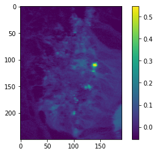

```python
#write code for PCA and approximate each data vector using few significant eigen values
P = P.T
A=P
A = A.T
Y = np.matmul(A,X_centered)


total = sum(E)
var_exp = [(i / total)*100 for i in sorted(E, reverse=True)]
cum_var_exp = np.cumsum(var_exp)

print("values for how much you are droping")
print(cum_var_exp)
# print(len(cum_var_exp))
print("Enter the number of principal eigenvectors <= ",len(cum_var_exp))
q=int(input())
PP = A.T
PP = PP[:,:-q]
YY = Y[:-q,]

Xr= np.dot(PP,YY)
X1r = np.reshape(Xr[0,:],[191,250])
plt.imshow(X1r.T)
plt.colorbar()
```

## 4. Data generating process:

In this experiment take two zero mean, unit variance, uncorrelated Gaussian random variables. Obtain the transformation matrix $A$ in $Y = A \times X$ such that $Y$ has a specified covariance matrix. (Take any valid covariance matrix in this case) Hint: $$Y=AX$$ $$C_Y=AC_XA^T$$ Digonalize $$C_Y=U\Sigma U^{-1}$$ So, $$U\Sigma^{\frac{1}{2}}\Sigma^{\frac{1}{2}} U^{-1}=AC_XA^T$$ If, $X$ is uncorrelated then $C_X$ must be identity.
Hint for Code: Use np.linalg.eig, np.diag, np.matmul, np.cov

```python
#  For example use this Cy
Cy = np.array([[4 , 2],
               [2 , 4]])
print(Cy)
```

```
[[4 2]
 [2 4]]
```

```python
no_samples = 10
#generate the data using gausian distribution
mu, sigma = 0, 1 # mean and standard deviation
data=np.array(())
row1=np.array(())
row2=np.array(())
for i in range(10):
    data=np.append(data,np.random.normal(mu, sigma))
data=data.reshape(2,5)
print(data)

T =  np.random.rand(2,100)
print(T)
```

[output not shown]

```python
import math

def make(Cy):
    no_samples = 1000

    #Write code here
    data =  np.random.rand(2,1000)
    print(data)

    C_x = np.cov(data)

    U,V = np.linalg.eig(Cy)
    print("eigen values ",U)
    print("eigen vectors \n",V)
    V=V.transpose()

#diag matrix

    sigma=np.array(())
    for i in U:
        sigma=np.append(sigma,math.sqrt(i))
        diagonal_matrix = np.diag(sigma)
    print(diagonal_matrix)

#find A
    A=np.dot(V,diagonal_matrix)


#new Cy
    acx=np.matmul(A,C_x)
    Cynew=np.matmul(acx,A.T)
    print("Cy_new=",Cynew)

# print("Cy_new=",Cynew)
```

```python
Cy = np.array([[4 , -3],
[-3 , 4]])
print(Cy)
make(Cy)
```

```
[[ 4 -3]
 [-3  4]]
[[0.35886983 0.2923909  0.20332488 ... 0.69370761 0.06124025 0.52386007]
 [0.24044066 0.39573068 0.49337223 ... 0.87996862 0.16862859 0.37571419]]
eigen values  [7. 1.]
eigen vectors
 [[ 0.70710678  0.70710678]
 [-0.70710678  0.70710678]]
[[2.64575131 0.        ]
 [0.         1.        ]]
Cy_new= [[0.31699259 0.24545343]
 [0.24545343 0.34571818]]
```

```python
Cy = np.array([[10 , 6],
[6 , 10]])
print(Cy)
make(Cy)
```

```
[[10  6]
 [ 6 10]]
[[0.64551134 0.59851183 0.82476974 ... 0.46577787 0.70581223 0.09674135]
 [0.69629396 0.76994996 0.61868351 ... 0.55610233 0.25857426 0.75477813]]
eigen values  [16.  4.]
eigen vectors
 [[ 0.70710678 -0.70710678]
 [ 0.70710678  0.70710678]]
[[4. 0.]
 [0. 2.]]
Cy_new= [[ 0.74996847 -0.45851706]
 [-0.45851706  0.83774136]]
```

### Homework: Consider providing more valid covariance matrices and generate correlated random data using the reverse PCA operation done in Problem-4. This is an instance of data generating process useful in machine learning algorithms.